# Статистические тесты

22/11/2016

## Задача

- Хотим понять, отличаются ли группы по какому-то показателю
  - действительно ли мужчины чаще становятся руководителями, чем женщины
  - действительно ли определенная диета оказывает влияние на здоровье
  - действительно ли есть разница в уровне дохода между теми, у кого есть ученая степень, и теми, у кого ее нет
  - действительно ли оценка по математике связана с типом темперамента студента
  - …

## Данные

Oценки по математике и социологии для экономистов и социологов (+ перцентиль в соответствующем рейтинге, нормированная оценка, специальность и запись на майнор)

| id | percentile | abs | Soc | Math | Major | DS_minor |
| --- | --- | --- | --- | --- | --- | --- |
| 1 | 1 | 0.8924 | 9 | 8 | Экон | TRUE |
| 2 | 0.9942 | 0.8625 | 8 | 9 | Экон | TRUE |
| 3 | 0.9884 | 0.8316 | 9 | 8 | Экон | FALSE |

## Сравним оценки: социология

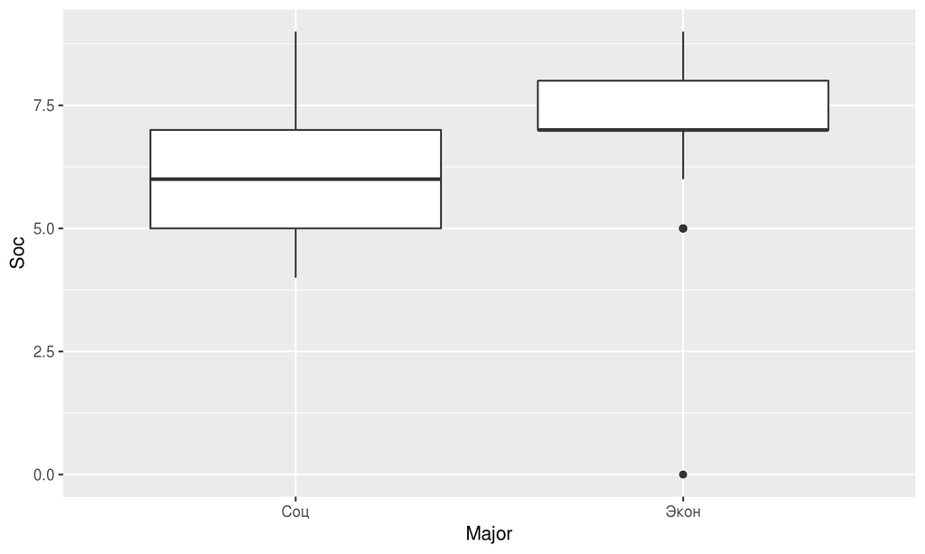

## Сравним оценки: математика

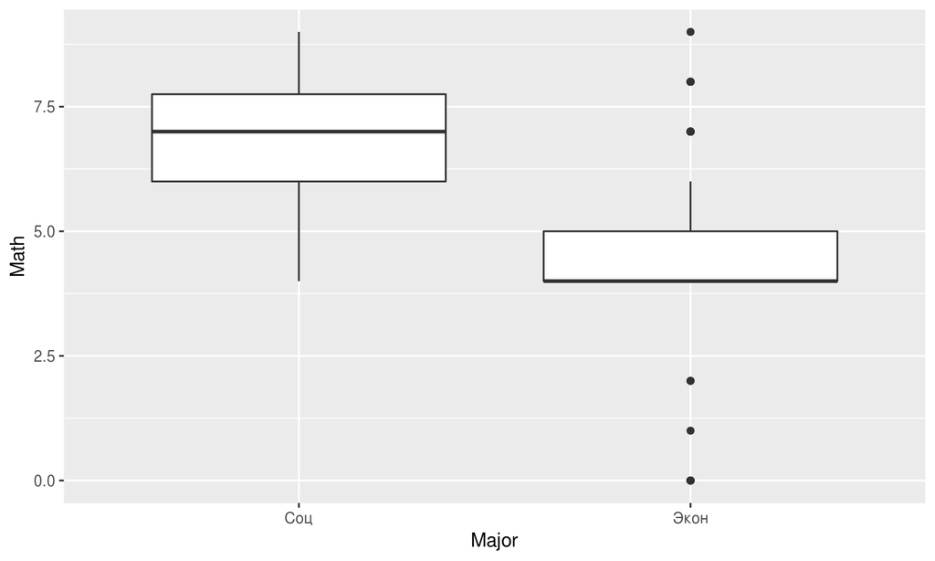

## Сравним оценки: социология и майнор

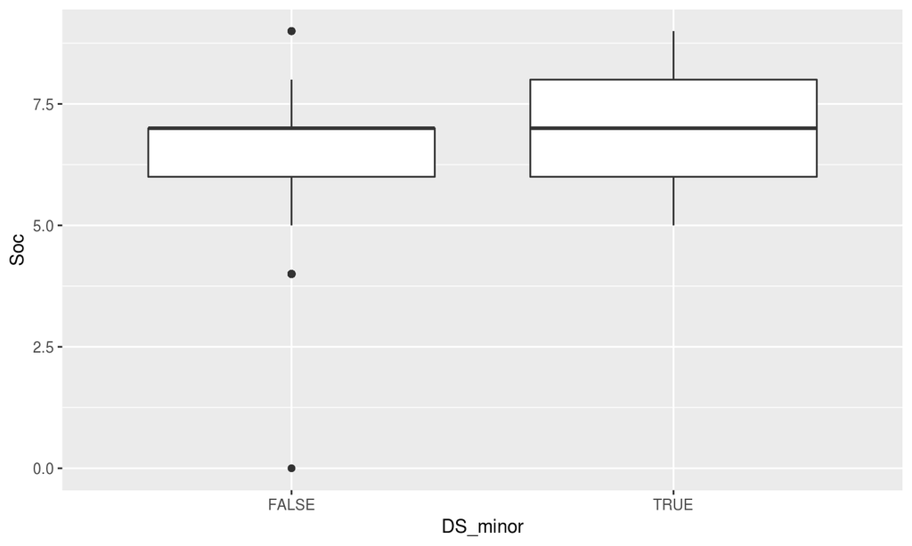

[figure not shown]

Разница между средними: -0.7708154

## Интерпретация

Итак, разница между средними = -0.7708154

- Велика ли эта разница?
- Есть какая-то закономерность, приводящая к разнице оценок, или это всего лишь случайность?

## Гипотезы

- Формулируем гипотезу (нуль-гипотезу)
- Проверяем, верна ли она (по тем данным, что у нас есть)

**При тестировании мы предполагаем, что нуль-гипотеза истинна.**

Хорошая цитата из википедии на английском…

- "This is often expressed in the phrase **innocent until proven guilty**, coined by the English lawyer Sir William Garrow. Garrow insisted that accusers be *robustly tested in court*. An objective observer in the position of the juror must **reasonably conclude that the defendant almost certainly committed the crime**." (Wikipedia)

## Проверка гипотезы

1. Сформулируем наш вопрос на языке статистики (то есть определим \(H_0\) и \(H_A\))
   - Например: \(H_0:\) Средняя оценка по социологии одинаковая для экономистов и социологов; \(H_A:\) Средние оценки различаются.
2. Выберем уровень значимости (\(\alpha\) – допустимая вероятность **ошибочно** отклонить **истинную** \(H_0\))
3. Определим подходящую к нашим данным статистику и вычислим ее.
4. Проверим, достаточно ли у нас оснований отклонить нулевую гипотезу (для выбранного значения \(\alpha\))
5. Сформулируем наши выводы на "человеческом" языке.

## Традиционный способ: t-критерий

```
##
##  Welch Two Sample t-test
##
## data:  Soc by Major
## t = -4.8146, df = 152.75, p-value = 3.516e-06
## alternative hypothesis: true difference in means is not equal to 0
## 95 percent confidence interval:
##  -1.0871081 -0.4545226
## sample estimates:
##  mean in group Соц mean in group Экон
##           6.223404           6.994220
```

- Что такое t-статистика?
- Почему она работает и почему именно ее мы использовали?
- Есть ли какие-то дополнительные условия, которые мы должны проверить?

## Random Permutation Test

**При тестировании мы предполагаем, что нуль-гипотеза истинна.**

- предполагаем, что в среднем разницы нет
- тогда если мы перемешаем наши оценки и раздадим их случайно, то особо ничего измениться не должно.

Давайте случайно перемешивать оценки и записывать разницу между средней оценкой социологов и средней оценкой экономистов.

- перемешали -> посчитали среднее по группе -> нашли разницы между группами -> записали значение
- повторили много раз

## Разница между средними

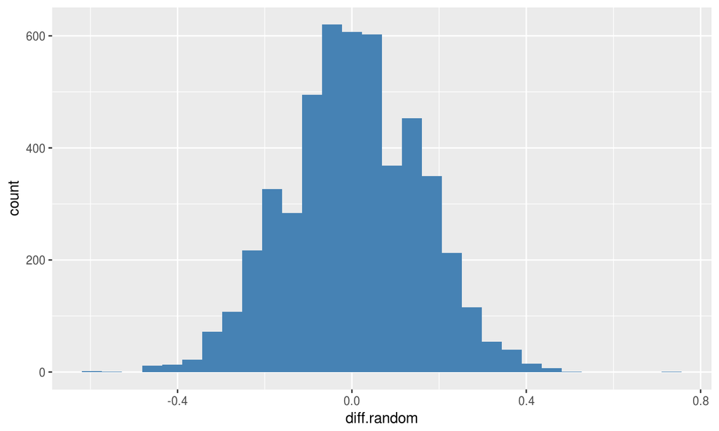

## Разница между средними

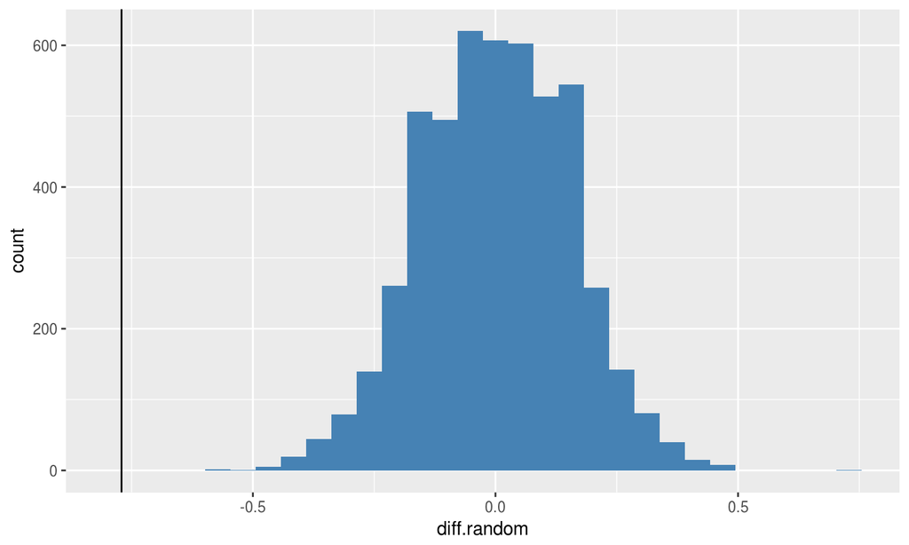

## 5% критическая область

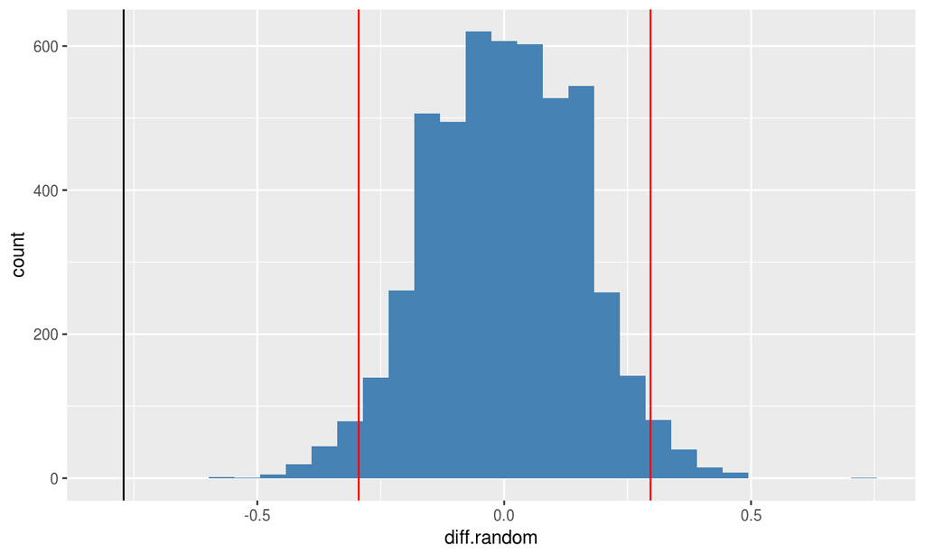

## P-values и всякое

**P-value** это вероятность получить такой же результат, как есть в данных, или еще больший, **при условии, что верна нуль-гипотеза**.

В нашем случае посчитать примерное значение p-value очень просто, это доля случаев с большей разницей, чем была в наблюдении. Посчитаем количество перестановок у которых разность была больше и поделим на общее число экспериментов.

```
## [1] 0
```

## Еще один пример

Сравним пришедших и не пришедших на майнор, с точки зрения оценки по социологии.

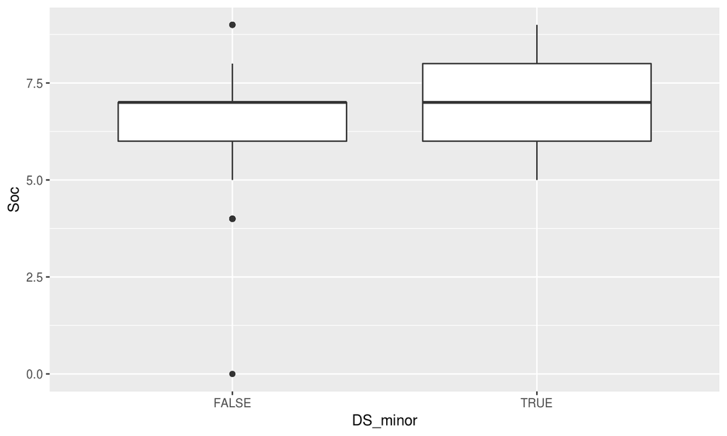

## Еще один пример

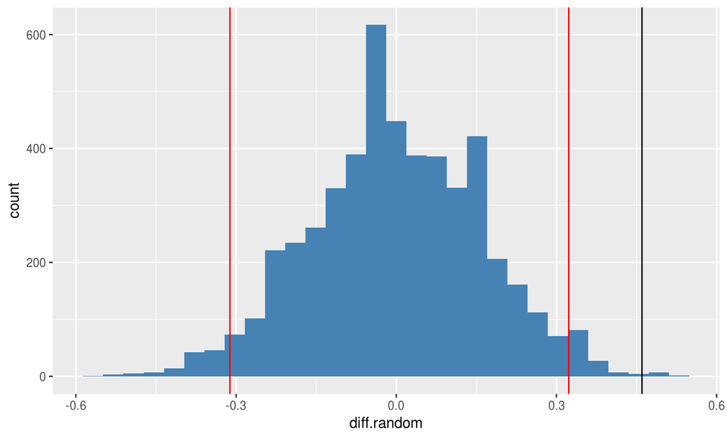

## Разные полезности

- Сравните результаты t-теста и теста перестановок
- [Krzywinski, M., Altman, N., 2013. Points of significance: Significance, P values and t-tests. Nat Meth 10, 1041–1042. doi:10.1038/nmeth.2698](http://www.nature.com/nmeth/journal/v10/n11/full/nmeth.2698.html)

### Playing) List

- https://www.youtube.com/watch?v=5Dnw46eC-0o
- http://spark.rstudio.com/ahmed/permutation/
- http://www.nature.com/nmeth/journal/v10/n11/full/nmeth.2698.html
- http://www.burns-stat.com/documents/tutorials/the-statistical-bootstrap-and-other-resampling-methods-2/#permtest
- http://cran.r-project.org/web/packages/coin/vignettes/coin_implementation.pdf

## Возвращаясь к t-критерию

- перемешивать/пересчитывать много раз – это не совсем удобно
- придумали более короткий вычислительно способ
- но нужно соблюдать предположения
  - только сравнение средних
  - выборка случайна и независима
  - значения распределены нормально

## t-критерий

```
##
##  Welch Two Sample t-test
##
## data:  abs by Major
## t = 9.9652, df = 219.8, p-value < 2.2e-16
## alternative hypothesis: true difference in means is not equal to 0
## 95 percent confidence interval:
##  0.09309922 0.13900163
## sample estimates:
##  mean in group Соц mean in group Экон
##          0.7415902          0.6255398
```

## t-критерий

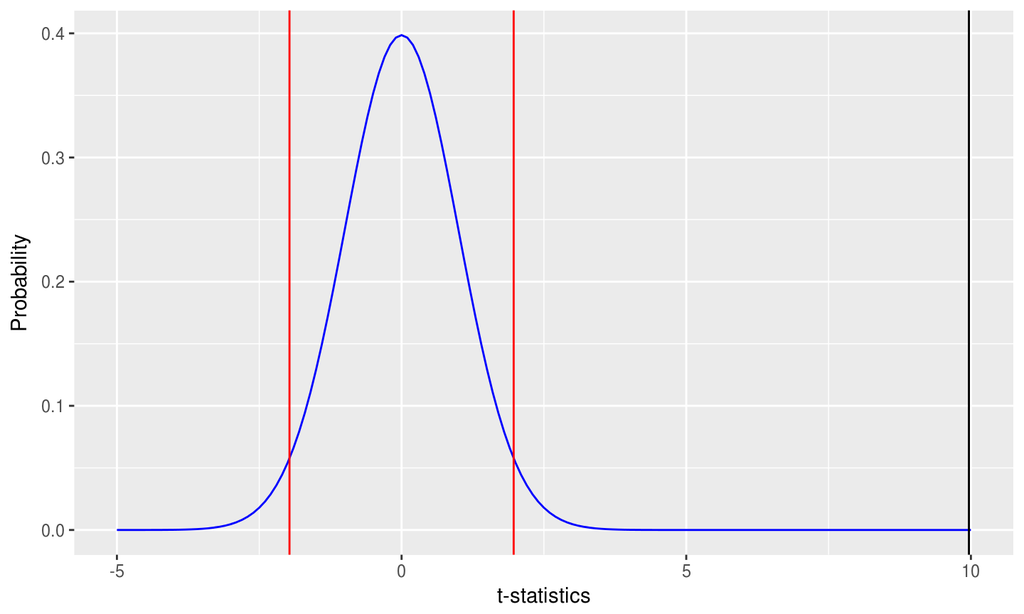

## Задача

- Хотим понять, отличаются ли группы по какому-то показателю
- Что делать, если среднее посчитать нельзя?
  - в каких случаях так происходит? Примеры?

## Категориальные переменные?

- Пол
- Национальность
- Семейный статус
- Религия
- …

## Гипотеза

- Хотим проверить, есть ли взаимосвязь между двумя категориальнымии переменными
- Нуль-гипотеза: взаимосвязи нет
- Альтернативная гипотеза: ?

## Гипотеза

- Хотим проверить, есть ли взаимосвязь между двумя категориальнымии переменными
- Нуль-гипотеза: взаимосвязи нет
- Альтернативная гипотеза: взаимосвязь есть

## Хи-квадрат: основная идея

Сравним **частоты**, наблюдаемые в каждой категории, и те **частоты**, что можно было бы ожидать, если бы распределение по категориям былло случайно

\[\chi^2 = \sum \frac{(observed_{ij}-model_{ij})^2}{model_{ij}}\]

где *i* – строка в таблице сопряженности, а *j* – столбец

## Пример

|  | Food | Affection | Total |
| --- | --- | --- | --- |
| **Yes** | 28 | 48 | 76 |
| **No** | 10 | 114 | 124 |
| **Total** | 38 | 162 | 200 |

## Ожидаемые значения

\[Model_{ij} = E_{ij} = \frac{\text{row total}_i * \text{column total}_j}{n}\]

\[Model_{Food,Yes} = \frac{RT_{Yes} * CT_{Food}}{n} = \frac{76 * 38}{200} = 14.44\]

\[Model_{Food,No} = \frac{RT_{No} * CT_{Food}}{n} = \frac{124 * 38}{200} = 23.56\]

\[Model_{Affection,Yes} = \frac{RT_{Yes} * CT_{Affection}}{n} = \frac{76 * 162}{200} = 61.56\]

\[Model_{Affection, No} = \frac{RT_{No} * CT_{Affection}}{n} = \frac{124 * 162}{200} = 100.44\]

## Считаем на примере

\[\chi^2 = \frac{(28-14.44)^2}{14.44} + \frac{(10-23.56)^2}{23.56} + \frac{(48-61.56)^2}{61.56} + \\ \frac{(114-100.44)^2}{100.44} = 25.35\]

## Отклонения от ожидаемого

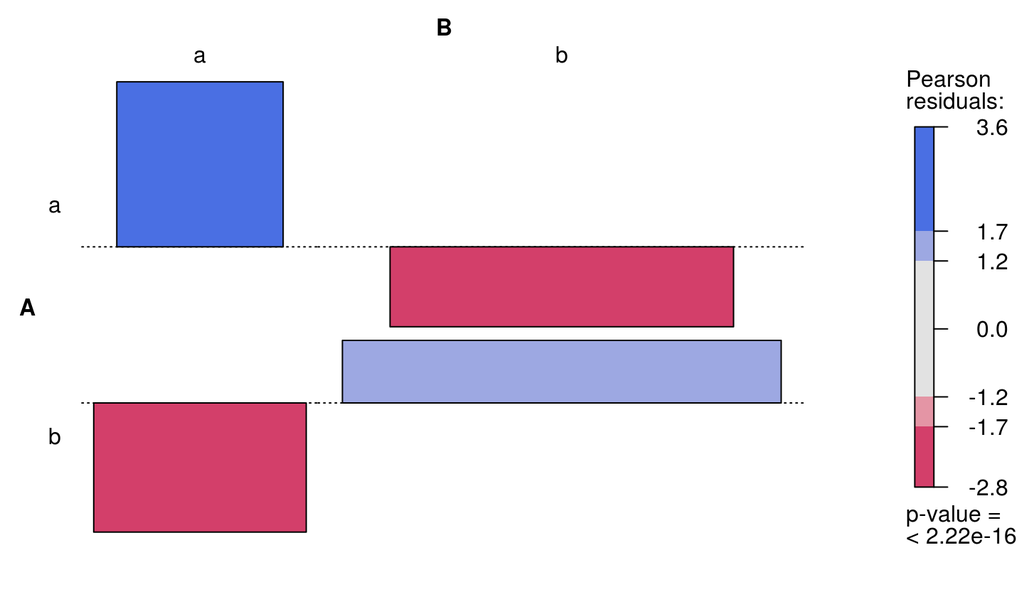

## Вернемся к студентам и оценкам

|  | FALSE | TRUE |
| --- | --- | --- |
| **Соц** | 59 | 35 |
| **Экон** | 122 | 51 |

```
##
##  Pearson's Chi-squared test with Yates' continuity correction
##
## data:  rates$Major and rates$DS_minor
## X-squared = 1.3409, df = 1, p-value = 0.2469
```

## Тест Хи-квадрат

Наблюдаемое:

|  | FALSE | TRUE |
| --- | --- | --- |
| **Соц** | 59 | 35 |
| **Экон** | 122 | 51 |

Ожидаемое:

|  | FALSE | TRUE |
| --- | --- | --- |
| **Соц** | 63.72 | 30.28 |
| **Экон** | 117.3 | 55.72 |

## Таблица Пирсоновских остатков

|  | FALSE | TRUE |
| --- | --- | --- |
| **Соц** | -0.5916 | 0.8583 |
| **Экон** | 0.4361 | -0.6327 |

## Отклонения от ожидаемого

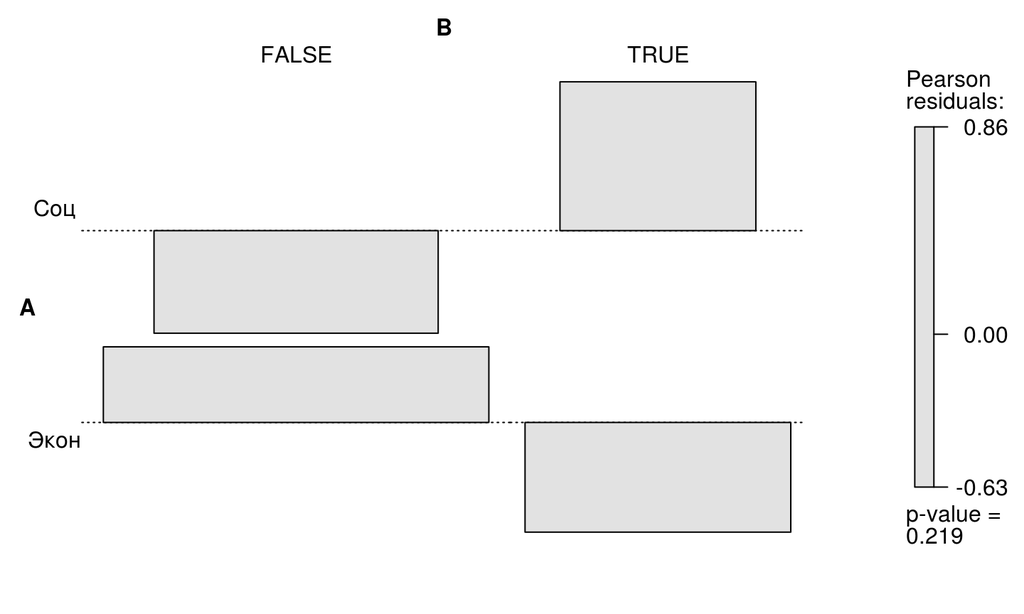